# Practical Machine Learning - Course Project

Huy Nguyen

July 24, 2021

# Overview

In this report, we will use data from accelerometers on the belt, forearm, arm, and dumbell of 6 participants. They were asked to perform barbell lifts correctly and incorrectly in 5 different ways.

Our goal is to predict the manner in which they did the exercise. This manner is defined by the “classe” variable in the training dataset.

The training data for this project are available here: https://d396qusza40orc.cloudfront.net/predmachlearn/pml-training.csv

The test data are available here: https://d396qusza40orc.cloudfront.net/predmachlearn/pml-testing.csv

# 1. Loading libraries and data

NB: To run this R code, the 2 data files (pml-training.csv and pml-testing.csv) must be put in the current working directory.

```r
library(knitr)
library(caret)
library(randomForest)
#Training data file must be in working directory
trainingData <- read.csv("pml-training.csv")
dim(trainingData)
```

```
## [1] 19622   160
```

The training dataset has 19622 observations of 160 variables.

Since the training dataset is quite large, we will choose the RandomForest model which gives quite high accuracy while lowering the risk of overfitting for large dataset.

# 2. Cleaning data

The inspection of the pml-training.csv file shows that  
- the first 7 variables are not relevant to the calculation. They are all about index, user name, time stamp and windows  
- there are lots of “NA”, "" and “#DIV/0!” values

First we will remove the first 7 variables.  
Then we will remove those containing “NA”,"“,”#DIV/0!".  
Finally we will remove near zero variance ones.

```r
#Removing first 7 variables irrelevant to the outcome
trainingData <- trainingData[,-c(1:7)]

#Remove NAs variables. Create a matrix where element "TRUE" indicates "NA"
d1 <- is.na(trainingData)

#Sum the values of each column. If sum=0, there is no "NA" in this column.
#Keep only columns with useful values
trainingData <- trainingData[,colSums(d1) == 0]

#Removing near zero variance variables
nzv <- nearZeroVar(trainingData)
trainingData <- trainingData[,-nzv]
dim(trainingData)
```

```
## [1] 19622    53
```

The number of variables has been reduced to 53.

# 3. Partitioning and constructing RandomForest model

Partition the training data to train/test sets, then construct the RandomForest model using a 3-folds cross validation.

```r
#Create partition into train and test dataset
inTrain  <- createDataPartition(y=trainingData$classe, p=0.7, list=FALSE)
trainSet <- trainingData[ inTrain,]
testSet  <- trainingData[-inTrain,]

#Set seed for reproducibility
set.seed(1234)

#3-folds cross validation
control <- trainControl(method="cv", number=3, verboseIter=FALSE)

#Construct the RandomForest model
modRF <- train(classe ~ ., data=trainSet, method="rf", trControl = control)
modRF
```

```
## Random Forest
##
## 13737 samples
##    52 predictor
##     5 classes: 'A', 'B', 'C', 'D', 'E'
##
## No pre-processing
## Resampling: Cross-Validated (3 fold)
## Summary of sample sizes: 9159, 9158, 9157
## Resampling results across tuning parameters:
##
##   mtry  Accuracy   Kappa
##    2    0.9872610  0.9838825
##   27    0.9877706  0.9845287
##   52    0.9812194  0.9762383
##
## Accuracy was used to select the optimal model using the largest value.
## The final value used for the model was mtry = 27.
```

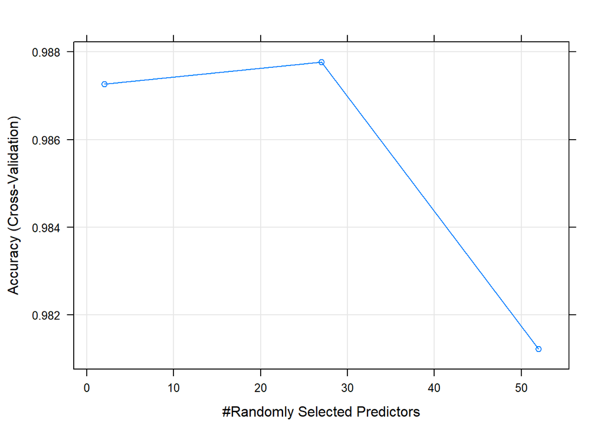

```r
#Plot the model
plot(modRF)
```

# 4. Prediction

Perform prediction using the partition test set.

```r
predRF <- predict(modRF, testSet)

#Check the accuracy of the model
cm <- confusionMatrix(predRF, factor(testSet$classe))
cm
```

```
## Confusion Matrix and Statistics
##
##           Reference
## Prediction    A    B    C    D    E
##          A 1670    8    0    0    0
##          B    2 1125    8    0    0
##          C    1    6 1012    7    1
##          D    0    0    6  957    2
##          E    1    0    0    0 1079
##
## Overall Statistics
##
##                Accuracy : 0.9929
##                  95% CI : (0.9904, 0.9949)
##     No Information Rate : 0.2845
##     P-Value [Acc > NIR] : < 2.2e-16
##
##                   Kappa : 0.991
##
##  Mcnemar's Test P-Value : NA
##
## Statistics by Class:
##
##                      Class: A Class: B Class: C Class: D Class: E
## Sensitivity            0.9976   0.9877   0.9864   0.9927   0.9972
## Specificity            0.9981   0.9979   0.9969   0.9984   0.9998
## Pos Pred Value         0.9952   0.9912   0.9854   0.9917   0.9991
## Neg Pred Value         0.9990   0.9971   0.9971   0.9986   0.9994
## Prevalence             0.2845   0.1935   0.1743   0.1638   0.1839
## Detection Rate         0.2838   0.1912   0.1720   0.1626   0.1833
## Detection Prevalence   0.2851   0.1929   0.1745   0.1640   0.1835
## Balanced Accuracy      0.9979   0.9928   0.9916   0.9956   0.9985
```

```r
#Print out accuracy
cm$overall[["Accuracy"]]
```

```
## [1] 0.9928632
```

As shown, accuracy is quite high and lies within the 95% confidence interval, as expected with a RandfomForest model for a large dataset.

# 5. Applying the Selected Model to the Test Data

Use the test data and predict the outcome for 20 observations with our Random Forest model.  
The results will be used to answer the questions in the “Course Project Prediction Quiz”.  
The test data has 20 observations and 160 variables.

```r
#Load test data
testData  <- read.csv("pml-testing.csv")
dim(testData)
```

```
## [1]  20 160
```

```r
#Apply our model to test data
pred <- predict(modRF, testData)
pred
```

```
##  [1] B A B A A E D B A A B C B A E E A B B B
## Levels: A B C D E
```